# SAE FOOT DONNEES DE LIGA

2025-01-02

Packages

```r
library(readxl)
library(dplyr)
library(ggplot2)
library(shiny)
```

# 1. Gestion des données

Importation des données

```r
X11_Liga <- read_excel("11_Liga.xlsx")
View(X11_Liga)
```

Description des données

```r
nrow(X11_Liga)  # Nombre d'observations
```

```
## [1] 529
```

```r
ncol(X11_Liga)  # Nombre de variables
```

```
## [1] 44
```

```r
sum(is.na(X11_Liga))  # Nombre de valeurs manquantes
```

```
## [1] 7314
```

Notre jeu de données regroupe 529 observations qui représentent les joueurs, avec 44 variables qui décrivent leurs caractéristiques footballistiques. Il contient également 7314 valeurs manquantes.

Pour simplifier le traitement des données, nous avons décidé de conserver uniquement les variables essentielles à notre analyse. On a crée Une nouvelle base de données, appelée ‘data’ et on a sélectionné que les variables d’intérêt : Club, Joueur, Buts, %Passes, Tirs, PossMid, Interceptions, Gross ocaz manquée, et Note.

```r
# Préparation des données :
data <- X11_Liga %>%
  mutate(Club = as.factor(Club)) %>%
  select(
    Club, Joueur, Buts, `%Passes`, Tirs, PossMid, Interceptions,
    `Gross ocaz manquée`, Note
  )
View(data)  # Aperçu des données traitées
```

# Analyse descriptive

Dans un premier temps, nous avons calculé la proportion de joueurs par poste afin de mieux comprendre la répartition des joueurs selon leurs positions sur le terrain.

```r
jr_poste <- X11_Liga %>%
  mutate(Poste = as.factor(Poste)) %>%
  group_by(Poste) %>%
  summarise(
    Effectif = n(),                     # Effectif total par poste
    Proportion = n() / nrow(data)       # Proportion de joueurs par poste
  )
print(jr_poste)
```

```
## # A tibble: 6 × 3
##   Poste Effectif Proportion
##   <fct>    <int>      <dbl>
## 1 A          107      0.202
## 2 DC          90      0.170
## 3 DL          87      0.164
## 4 G           58      0.110
## 5 MD          83      0.157
## 6 MO         104      0.197
```

On constate que les attaquants (A) représentent le poste le plus fréquent, avec 107 joueurs, soit 20,2 % de l’effectif total. Viennent ensuite les défenseurs centraux (DC) avec 90 joueurs, représentant 17,0 % de l’effectif. Les défenseurs latéraux (DL) comptent 87 joueurs, soit 16,4 %, tandis que les milieux offensifs (MO) regroupent 104 joueurs, représentant 19,7 % du total. Les milieux défensifs (MD) sont légèrement moins nombreux, avec 83 joueurs, soit 15,7 %. Enfin, les gardiens (G) sont les moins nombreux, avec 58 joueurs, soit 11,0 % de l’ensemble.

Afin de comparer les performances entre clubs et d’identifier des tendances ou des différences importantes dans le jeu des joueurs selon leur équipe. Nous avons créé un résumé statistique

```r
resum_stat <- data %>%
  group_by(Club) %>%
  summary()  # Moyenne, médiane, etc. pour chaque club
print(resum_stat)
```

```
##             Club        Joueur               Buts            %Passes
##  Las Palmas   : 29   Length:529         Min.   : 0.0000   Min.   : 16.67
##  Barcelona    : 28   Class :character   1st Qu.: 0.0000   1st Qu.: 72.38
##  Celta        : 28   Mode  :character   Median : 0.0000   Median : 78.23
##  Real Sociedad: 28                      Mean   : 0.7977   Mean   : 76.76
##  Athletic     : 27                      3rd Qu.: 1.0000   3rd Qu.: 84.85
##  Betis        : 27                      Max.   :16.0000   Max.   :100.00
##  (Other)      :362                                        NA's   :72
##       Tirs           PossMid      Interceptions    Gross ocaz manquée
##  Min.   : 1.000   Min.   : 1.00   Min.   : 1.000   Min.   : 1.000
##  1st Qu.: 3.000   1st Qu.: 6.00   1st Qu.: 2.000   1st Qu.: 1.000
##  Median : 7.000   Median :12.00   Median : 6.000   Median : 1.000
##  Mean   : 9.828   Mean   :14.51   Mean   : 7.249   Mean   : 2.227
##  3rd Qu.:13.000   3rd Qu.:21.00   3rd Qu.:10.000   3rd Qu.: 3.000
##  Max.   :69.000   Max.   :57.00   Max.   :36.000   Max.   :13.000
##  NA's   :133      NA's   :110     NA's   :144      NA's   :344
##       Note
##  Min.   :0.000
##  1st Qu.:4.680
##  Median :4.950
##  Mean   :4.557
##  3rd Qu.:5.220
##  Max.   :7.000
##
```

Pour mieux comprendre les performances offensives, nous avons d’abord créé un code pour analyser le nombre total de buts marqués par chaque club, en les regroupant et en les triant en fonction de leur performance offensive. en regroupant les données et en triant les clubs par performance offensive. Ensuite, nous avons filtré les clubs ayant marqué plus de 25 buts afin de sélectionner les meilleurs clubs pour une analyse plus approfondie.

```r
#Nombre de buts par club
but_club <- data %>%
  group_by(Club) %>%
  summarise(nb_buts = sum(Buts)) %>%
  arrange(desc(nb_buts))  # Tri des clubs par nombre total de buts
View(but_club)

#Les clubs ayant marqué plus de 25 buts
buts_club_filtrer <- but_club %>%
  filter(nb_buts > 25)
buts_club_filtrer
```

```
## # A tibble: 4 × 2
##   Club        nb_buts
##   <fct>         <dbl>
## 1 Barcelona        50
## 2 Real Madrid      37
## 3 Atlético         31
## 4 Athletic         27
```

```r
View(buts_club_filtrer)
```

```r
#La moyenne des buts des meilleurs clubs
moyenne_buts <- mean(buts_club_filtrer$nb_buts)
moyenne_buts
```

```
## [1] 36.25
```

La moyenne des buts marqués par les clubs filtrés est de 36,25

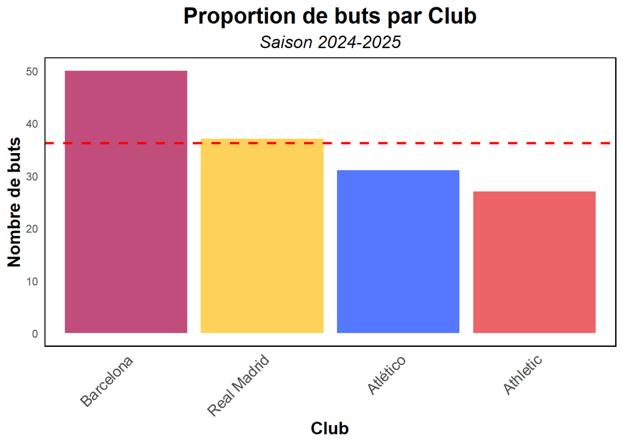

```r
# Visualisation des buts par club avec ggplot2
ggplot(buts_club_filtrer) +
  aes(x = reorder(Club, -nb_buts), y = nb_buts, fill = Club) +
  geom_col(alpha = 0.7) +
  scale_fill_manual(values = c(
    "Barcelona" = "#A50044",
    "Real Madrid" = "#FEBE10",
    "Atlético" = "#0A3DFF",
    "Athletic" = "#E41F26"
  )) +
  labs(
    title = "Proportion de buts par Club",
    subtitle = "Saison 2024-2025",
    x = "Club",
    y = "Nombre de buts"
  ) +
  theme_minimal() +
  theme(
    plot.title = element_text(size = 18, face = "bold", hjust = 0.5),
    plot.subtitle = element_text(size = 14, face = "italic", hjust = 0.5),
    axis.text.x = element_text(angle = 45, hjust = 1, size = 12),
    axis.title = element_text(size = 14, face = "bold"),
    legend.position = "none",
    panel.grid = element_blank(),
    panel.border = element_rect(color = "black", fill = NA, size = 0.8)
  ) +
  geom_hline(yintercept = moyenne_buts, linetype = "dashed", color = "red", size = 1)
```

Pour avoir un aperçu des styles de jeu des équipes et de leur capacité à créer des opportunités offensives.Nous avons calculer de la proportion de passes par club.

```r
# Calcul et visualisation de la proportion de passes par club
prop_passe_par_club <- data %>%
  group_by(Club) %>%
  summarise(prop_passes = sum(`%Passes`, na.rm = T) / n())
View(prop_passe_par_club)


View(prop_passe_par_club)
```

Un club avec une proportion de passes élevée pourrait être plus efficace dans la création d’occasions de but, même si ce n’est pas directement lié au nombre de buts.

On peut se demander si les clubs avec une meilleure proportion de passes réussies marquent-ils plus de buts ?

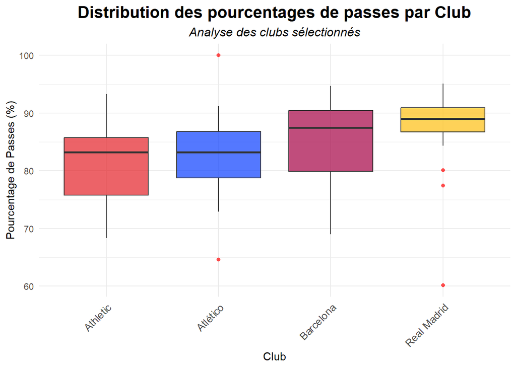

```r
#Pour réaliser les boîtes à moustaches :
# Analyse et visualisation des clubs spécifiques
clubs_specifiques <- c("Barcelona", "Real Madrid", "Atlético", "Athletic Bilbao")

buts_club_filtrer_selection <- data %>%
  filter(Club %in% clubs_specifiques) %>%
  arrange(desc(Buts))
# Liste des clubs à comparer
clubs_specifiques <- c("Barcelona", "Real Madrid", "Atlético", "Athletic")
# Filtrer les données pour les clubs spécifiés
data_clubs_specifiques <- data %>%
  filter(Club %in% clubs_specifiques)

# Visualisation des pourcentages de passes avec un boxplot
ggplot(data_clubs_specifiques) +
  aes(x = Club, y = `%Passes`, fill = Club) +
  geom_boxplot(alpha = 0.7, outlier.color = "red", outlier.shape = 16) +
  scale_fill_manual(values = c(
    "Barcelona" = "#A50044",        # Rouge grenat pour le FC Barcelone
    "Real Madrid" = "#FEBE10",      # Jaune doré pour le Real Madrid
    "Atlético" = "#0A3DFF",         # Bleu vif pour l'Atlético Madrid
    "Athletic" = "#E41F26"   # Rouge vif pour l'Athletic Bilbao
  )) +
  labs(
    title = "Distribution des pourcentages de passes par Club",
    subtitle = "Analyse des clubs sélectionnés",
    x = "Club",
    y = "Pourcentage de Passes (%)"
  ) +
  theme_minimal() +
  theme(
    plot.title = element_text(size = 16, face = "bold", hjust = 0.5),
    plot.subtitle = element_text(size = 12, face = "italic", hjust = 0.5),
    axis.text.x = element_text(angle = 45, hjust = 1, size = 10),
    legend.position = "none"
  )
```

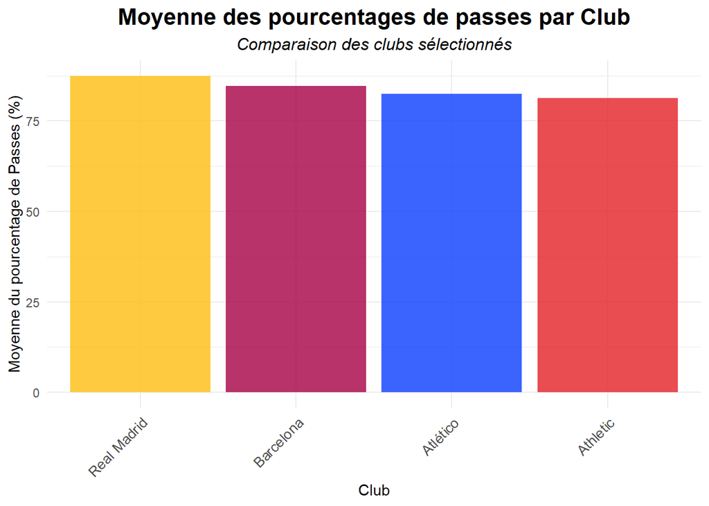

```r
# Analyse et visualisation des clubs spécifiques
clubs_specifiques <- c("Barcelona", "Real Madrid", "Atlético", "Athletic Bilbao")
buts_club_filtrer_selection <- data %>%
  filter(Club %in% clubs_specifiques) %>%
  arrange(desc(Buts))

#Pour réaliser le graphique de moyenne des pourcenatges de passes par club
# Calcul de la moyenne des pourcentages de passes pour chaque club sélectionné
mean_passes_per_club <- data_clubs_specifiques %>%
  group_by(Club) %>%
  summarise(mean_passes = mean(`%Passes`, na.rm = TRUE))

# Visualisation de moyenne des pourcentages de passes par club
ggplot(mean_passes_per_club) +
  aes(x = reorder(Club, -mean_passes), y = mean_passes, fill = Club) +
  geom_col(alpha = 0.8) +
  scale_fill_manual(values = c(
    "Barcelona" = "#A50044",        # Rouge grenat pour le FC Barcelone
    "Real Madrid" = "#FEBE10",      # Jaune doré pour le Real Madrid
    "Atlético" = "#0A3DFF",         # Bleu vif pour l'Atlético Madrid
    "Athletic" = "#E41F26"   # Rouge vif pour l'Athletic Bilbao
  )) +
  labs(
    title = "Moyenne des pourcentages de passes par Club",
    subtitle = "Comparaison des clubs sélectionnés",
    x = "Club",
    y = "Moyenne du pourcentage de Passes (%)"
  ) +
  theme_minimal() +
  theme(
    plot.title = element_text(size = 16, face = "bold", hjust = 0.5),
    plot.subtitle = element_text(size = 12, face = "italic", hjust = 0.5),
    axis.text.x = element_text(angle = 45, hjust = 1, size = 10),
    legend.position = "none"
  )
```

Ce graphique complète et confirme également les observations précédentes, Barcelone et Real Madrid dominent en termes de passes réussies, tandis qu’Atlético et Athletic ont des performances plus limitées.

Après avoir analysé les clubs les plus performants, nous avons décidé de nous concentrer sur le classement des meilleurs buteurs afin de comprendre quelles individualités ont eu le plus grand impact sur ces performances collectives

```r
# Analyse des meilleurs buteurs du championnat
classement_buteurs <- data %>%
  group_by(Joueur) %>%
  summarise(nb_buts = sum(Buts)) %>%
  arrange(desc(nb_buts))  # Tri des joueurs par nombre total de buts
View(classement_buteurs)

# Les meilleurs buteurs du championnat
View(classement_buteurs)
```

Le classement des buteurs met en tête Lewandowski avec 16 buts, suivi de Raphinha (11 buts) et Budimir (10 buts), tandis que Mbappé se place quatrième avec 9 réalisations.

Pour analyser les performances des joueurs de La Liga, nous avons développé une interface RShiny. Cette interface permet de visualiser un graphique qui représente les buts marqués des joeurscpar club, tout en offrant la possibilité de filtrer les résultats en fonction d’un seuil défini.

```r
# Interface utilisateur
ui <- fluidPage(
  titlePanel("Analyse des données de la Liga"),
  sidebarLayout(
    sidebarPanel(
      selectInput("club", "Sélectionnez un club :", choices = unique(data$Club)),
      numericInput("seuil", "Seuil de buts :", value = 0, min = 0),
      actionButton("update", "Mettre à jour")
    ),
    mainPanel(
      plotOutput("plot_buts")
    )
  )
)

# Serveur
server <- function(input, output) {
  filtered_data <- eventReactive(input$update, {
    data %>%
      filter(Club == input$club, Buts > input$seuil)
  })

  output$plot_buts <- renderPlot({
    ggplot(filtered_data()) +
      aes(x = Joueur, y = Buts, fill = Joueur) +
      geom_col() +
      labs(
        title = paste("Nombre de buts pour", input$club),
        x = "Joueur",
        y = "Buts"
      ) +
      theme_minimal() +
      theme(
        axis.text.x = element_text(angle = 45, hjust = 1, size = 10) # Inclinaison des noms
      )
  })
}

#Interface Rshiny
shinyApp(ui = ui, server = server)
```

Shiny applications not supported in static R Markdown documents

Pour mettre en évidence les liens potentiels entre la performance des joueurs (mesurée par leur note) et leur efficacité offensive (nombre de buts marqués) nous avons décidé de faire un graphique qui met en relation ces deux variables avec une ligne de régression qui suggère la tendance moyenne de la relation entre les deux variables.

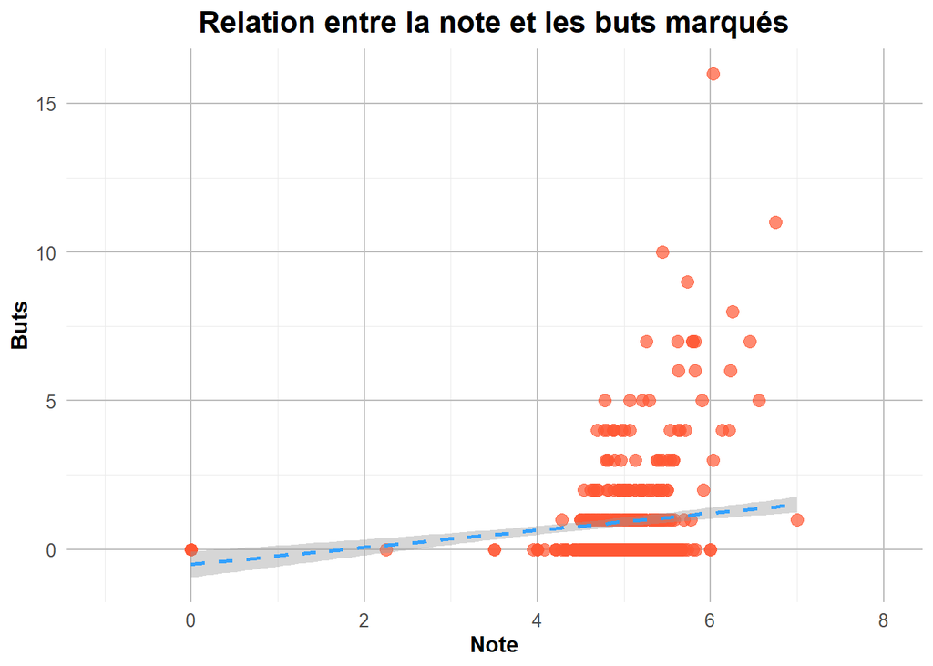

```r
ggplot(data) +
  aes(x = Note, y = Buts) +
  geom_point(color = "#FF5733", size = 3, alpha = 0.7) +  # Points avec une opacité
  geom_smooth(method = "lm", color = "#33A1FF", linetype = "dashed") +  # Ligne de régression
  labs(title = "Relation entre la note et les buts marqués", x = "Note", y = "Buts") +
  theme_minimal() +  # Application d'un thème minimal
  theme(
    plot.title = element_text(hjust = 0.5, size = 16, face = "bold"),  # Titre centré et stylisé
    axis.title = element_text(size = 12, face = "bold"),
    axis.text = element_text(size = 10),
    panel.grid.major = element_line(color = "gray", size = 0.5)
  ) +
  coord_cartesian(xlim = c(min(data$Note) - 1, max(data$Note) + 1))  # Ajuster les limites des axes si nécessaire
```

On constate une légère relation positive qui semble exister entre la note et le nombre de buts marqués. Cela signifie que les joueurs ayant une note plus élevée ont tendance à marquer plus de buts. La majorité des joueurs ont une note comprise entre 4 et 6. La plupart des joueurs marquent peu de buts (entre 0 et 5). Certains joueurs (avec une note autour de 6) se distinguent en marquant un nombre élevé de buts (plus de 10).